# STAC33-A10

Khusanbek Mukhammad Azim

08/04/2021

```r
library(tidyverse)
library(lubridate)
```

# Q.1

## (a)

Since the file is a .csv, we use read_csv.

```r
url <- "http://ritsokiguess.site/STAC33/sleeping.csv"
sleep <- read_csv(url)
sleep
```

```
## # A tibble: 7 x 3
##   bed.time            rise.time           sleep.time
##   <dttm>              <dttm>                   <dbl>
## 1 2013-09-01 23:05:24 2013-09-02 08:03:29       6.74
## 2 2013-09-02 22:51:09 2013-09-03 07:34:21       7.92
## 3 2013-09-04 00:09:16 2013-09-04 07:45:06       7.01
## 4 2013-09-04 23:43:31 2013-09-05 07:07:17       6.23
## 5 2013-09-06 00:17:41 2013-09-06 08:17:13       6.34
## 6 2013-09-06 22:42:27 2013-09-07 06:52:11       7.42
## 7 2013-09-08 00:22:27 2013-09-08 07:15:19       6.45
```

We have 7 rows and 3 columns. bed.time and rise.time columns display the date and time in YMD HMS format. The sleep.time column displays the hours sleeping in decimal format.

## (b)

First the period that the student spends in bed in hours is computed.

```r
sleep %>% mutate(t = as.period(bed.time %--% rise.time)) %>%
  mutate(time_in_bed = hour(t) + minute(t)/60) %>%
  select(-t) -> sleep2
sleep2
```

```
## # A tibble: 7 x 4
##   bed.time            rise.time           sleep.time time_in_bed
##   <dttm>              <dttm>                   <dbl>       <dbl>
## 1 2013-09-01 23:05:24 2013-09-02 08:03:29       6.74        8.97
## 2 2013-09-02 22:51:09 2013-09-03 07:34:21       7.92        8.72
## 3 2013-09-04 00:09:16 2013-09-04 07:45:06       7.01        7.58
## 4 2013-09-04 23:43:31 2013-09-05 07:07:17       6.23        7.38
## 5 2013-09-06 00:17:41 2013-09-06 08:17:13       6.34        7.98
## 6 2013-09-06 22:42:27 2013-09-07 06:52:11       7.42        8.15
## 7 2013-09-08 00:22:27 2013-09-08 07:15:19       6.45        6.87
```

The fractional time in hours that each student was in bed is given below.

```r
sleep2 %>% select(time_in_bed)
```

```
## # A tibble: 7 x 1
##   time_in_bed
##         <dbl>
## 1        8.97
## 2        8.72
## 3        7.58
## 4        7.38
## 5        7.98
## 6        8.15
## 7        6.87
```

## (c)

We compute sleep efficiency be dividing the sleep time and time in bed and multiplying result by 100 to get a percentage.

```r
# compute sleep efficiency
sleep2 %>%
  mutate(sleep_efficiency = (sleep.time/time_in_bed)*100) %>%
  select(bed.time, sleep_efficiency)
```

```
## # A tibble: 7 x 2
##   bed.time            sleep_efficiency
##   <dttm>                         <dbl>
## 1 2013-09-01 23:05:24             75.2
## 2 2013-09-02 22:51:09             90.9
## 3 2013-09-04 00:09:16             92.4
## 4 2013-09-04 23:43:31             84.4
## 5 2013-09-06 00:17:41             79.4
## 6 2013-09-06 22:42:27             91.0
## 7 2013-09-08 00:22:27             93.9
```

The greatest sleep efficiency of 93.93% was achieved on the night of September 8, 2013.

## (d)

The time spend in bed formatted as H:M:S is given by determining the period from bed.time to rise.time.

```r
sleep %>%
  mutate(time = as.period(bed.time %--% rise.time)) %>%
  select(bed.time, time)
```

```
## # A tibble: 7 x 2
##   bed.time            time
##   <dttm>              <Period>
## 1 2013-09-01 23:05:24 8H 58M 5S
## 2 2013-09-02 22:51:09 8H 43M 12S
## 3 2013-09-04 00:09:16 7H 35M 50S
## 4 2013-09-04 23:43:31 7H 23M 46S
## 5 2013-09-06 00:17:41 7H 59M 32S
## 6 2013-09-06 22:42:27 8H 9M 44S
## 7 2013-09-08 00:22:27 6H 52M 52S
```

## (e)

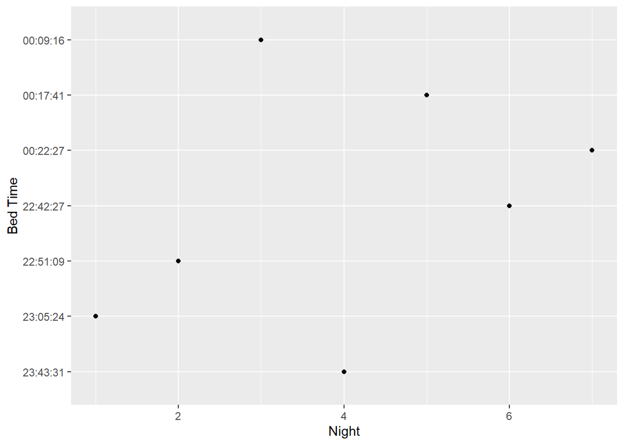

```r
sleep %>%
  mutate(bed_time = format(sleep$bed.time, format='%H:%M:%S')) %>%
  tibble(Night = 1:7, time_in_bed=bed_time) %>%
  ggplot(aes(x=Night, y=time_in_bed)) + geom_point() + scale_y_discrete(limits=rev) + ylab("Bed Time")
```

# Q.2

## (a)

```r
url <- "http://ritsokiguess.site/STAC32/heightfoot.csv"
ht <- read_csv(url)
ht
```

```
## # A tibble: 33 x 2
##    height  foot
##     <dbl> <dbl>
##  1   66.5  27
##  2   73.5  29
##  3   70    25.5
##  4   71    27.9
##  5   73    27
##  6   71    26
##  7   71    29
##  8   69.5  27
##  9   73    29
## 10   71    27
## # ... with 23 more rows
```

We have 33 rows and 2 columns.

## (b)

Height is the response variable and foot is the explanatory variable.

```r
# compute beta hat

x <- matrix(c(rep(1,33), ht$foot), nrow=33)
y <- ht$height

# calculate inverse
a <- solve(t(x)%*%x)

# calculate transpose of x time y
b <- t(x)%*%y

# beta hat
b_hat <- a%*%b
b_hat
```

```
##           [,1]
## [1,] 34.336335
## [2,]  1.359062
```

The intercept is 34.336335 and the slope is 1.359062.

## (c)

```r
ht.lm <- lm(height~foot, data=ht)
summary(ht.lm)$coefficients
```

```
##              Estimate Std. Error  t value     Pr(>|t|)
## (Intercept) 34.336335  9.9540750 3.449475 0.0016403485
## foot         1.359062  0.3580795 3.795420 0.0006428437
```

The correct intercept is 34.336335 and correct slope is 1.359062 which are identical to the calculated values.